# Introduction to Tidyverse (1)

BIOSTAT 830, Winter 2020

Jie Cao (caojie@umich.edu)

April 21, 2020

## About

(Source: https://rviews.rstudio.com/2017/06/08/what-is-the-tidyverse/)

In this tutorial, I am going to introduce *tidyverse* style guide, pipe, and *dplyr* to give you a flavor of *tidyverse.* They are essential elements in tidyverse-style programming, and I believe you will start to fall in love with *tidyverse* soon.

## Style Guide

A programming style guide is an opinionated guide of programming conventions, style and best practices for a team or a project. It is not compulsory (youcanmanageyourcodewithoutit), but it will make your and your colleagues’ life easier in the future. All style guides are different, depending on the programming language characteristics and projects’ need. Actually, many decisions are arbitrary. However, the most important role of style guide is to ensure consistency, readability of the code and make it easier to write.

*Tidyverse* provides a well-documented [*tidyverse* style guide](https://style.tidyverse.org/) that is used throughout the *tidyverse*. The style guide was derived from Google’s original R Style guide, but now [Google’s R Style Guide](https://google.github.io/styleguide/Rguide.html) is derived from *tidyverse* style guide 😆.

### Elements

| Style Element | Description |
| --- | --- |
| Header | An informative summary of the script, elements including but not limited to: Title: should be short and concise Author: include your name and contact information Date: last modified date Input: if any… |
| Naming | `dot.case`: separate words with a period (R convention) `CamelCase`: Capitalize the first letter of words (Google’s R Style Guide) `snake_case`: separate words with an underscore (*tidyverse* style gu… |
| Formatting | Indentation: indent contents/an addtional level by two spaces Spacing: space before and after most special characters; put a space after # when writing comments; extra spaces may be allowed for alignm… |
| Comments | Appropriately use comments throughout the script to organize the script and clarify chunks of code |

This is a non-exhaustive list of style elements. For more details and examples, please refere to [*tidyverse* style guide](https://style.tidyverse.org/).

### Template

Here is an example template I created that you can use to start your R script. In addition to header, I also incorporate long line restriction (80 characters) and chunk order in this template.

```r
#################################################################
# Biostat 830, Winter 2020
# Final Project
#----------------------------------------------------------------
# Describe your R script here in a few lines.
# This is a good place to document data input(s)/output(s).
#----------------------------------------------------------------
# Author: Your name (you email @umich.edu)
# Updated on: Apr 21, 2020 - Last modified date
#################################################################

# 80: --------------------------------------------------------------------------

# libraries: -------------------------------------------------------------------
library(tidyverse)

# directories: -----------------------------------------------------------------

# data: ------------------------------------------------------------------------

# 80: --------------------------------------------------------------------------
```

### Tips

1. Be creative about buiding your comment block!

```r
library(bannerCommenter)
banner("Section 1:", "Data input and initialization", fold = T)
```

```
##
## ##################################################################
## ##  Section 1: Data input and initialization                    ##
## ##################################################################
```

```r
banner("Section 1:", "Data input and initialization", bandChar = "=")
```

```
##
## ##===============================================================
## ##                          Section 1:                         ==
## ##                Data input and initialization                ==
## ##===============================================================
```

```r
banner("Section 1:", "Data input and initialization", bandChar = "~", emph = TRUE)
```

```
##
## ###~~~~~~~~~~~~~~~~~~~~~~~~~~~~~~~~~~~~~~~~~~~~~~~~~~~~~~~~~~~~~~~~~~~~~~~~
## ###~~~~~~~~~~~~~~~~~~~~~~~~~~~~~~~~~~~~~~~~~~~~~~~~~~~~~~~~~~~~~~~~~~~~~~~~
## ###                                                                     ~~~
## ###                              SECTION 1:                             ~~~
## ###                    DATA INPUT AND INITIALIZATION                    ~~~
## ###                                                                     ~~~
## ###~~~~~~~~~~~~~~~~~~~~~~~~~~~~~~~~~~~~~~~~~~~~~~~~~~~~~~~~~~~~~~~~~~~~~~~~
## ###~~~~~~~~~~~~~~~~~~~~~~~~~~~~~~~~~~~~~~~~~~~~~~~~~~~~~~~~~~~~~~~~~~~~~~~~
```

2. Let computer manage the style for you!

```r
library(styler)
```

`style_text()` styles a character vector;

`style_file()` styles R and Rmd files;

`style_dir()` styles all R and/or Rmd files in a directory;

`style_pkg()` styles the source files of an R package.

**Note**: Except `style_text()`, all other functions modify *in place*, which means your source file(s) will be overwritten. Therefore, I strongly advise to back up your files or use version control.

```r
ugly_code <- "a=function( x){1+1}           "
style_text(ugly_code)
```

```
## a <- function(x) {
##   1 + 1
## }
```

**Note**: Package`prettycode` can be helpful to display pretty code in the output.

Alternatively, you can use the RSudio **Addins**.

```r
foo<-function(x,y, z ){
stopifnot(length(x) ==length(y) )
#this is a comment
  data %>% filter(x==1) %>% ggplot(aes(x,y, group=z)) +geom_point()
  #this is another comment
sum( sqrt( diff( x )^2 + diff( y )^2 ) )
}
```

We can either select part of code to run `Style selection` or run `Style active file` to style the entire active file, depending on your purpose. Here I use `Style selection` as an example.

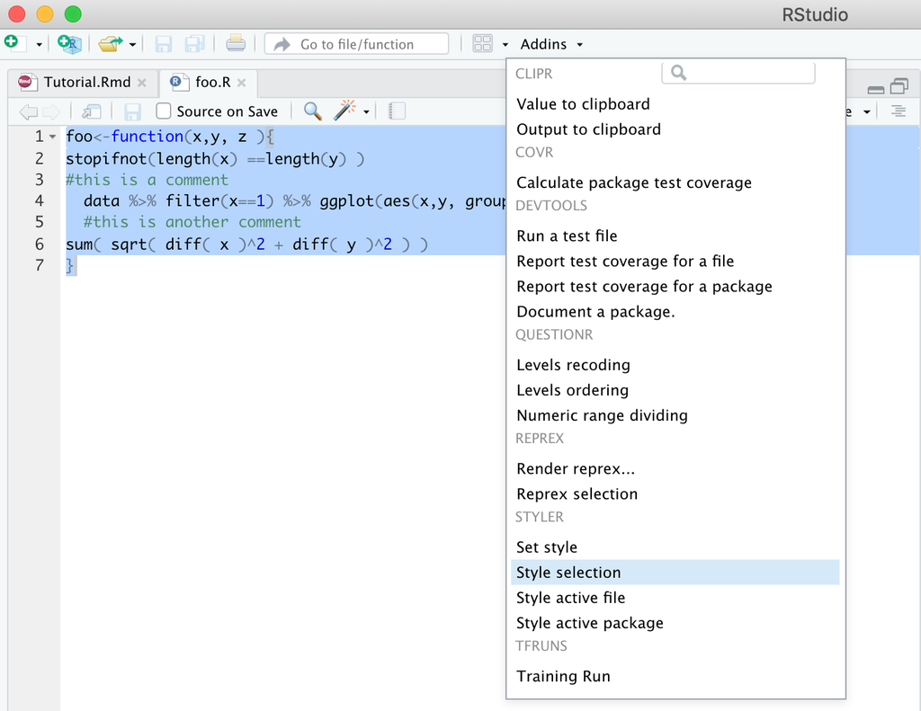

Then the computer will automatically style your code as following, which strictly follows the *tidyverse* style guide.

```r
foo <- function(x, y, z) {
  stopifnot(length(x) == length(y))
  # this is a comment
  data %>%
    filter(x == 1) %>%
    ggplot(aes(x, y, group = z)) +
    geom_point()
  # this is another comment
  sum(sqrt(diff(x)^2 + diff(y)^2))
}
```

## Pipe

Smoking harms your health, but pipe benefits your health (when programming in R)!

Programming used to be painful to me because:

1. A complicated mathmatical formula or workflow usually contains multiple levels of parentheses, which is hard for both typing and reading.
2. An alternative to reduce the level of parentheses is to create intermediate objects, which is not good for storage management especially when you are working with large datasets, like EHR.

You probably already notice this symbol `%>%` in the code block above. This is called pipe operator. It comes from the `magrittr` package. Basically, it takes the object on the LHS and fills it to the RHS as the first argument. If the LHS should not be filled as the first argument, you can use `.` to refer it at the appropriate position. The idea of pipe comes from Linux system - use the special character `|` for redirection. Forward-thinking is the core philosophy of piping.

Let’s say we have two functions, $f: A \rightarrow B$ and $g: B \rightarrow C$. If we are going to chain them together, then we have function $g(f(x))$ where $x$ serves as the input of $f(\cdot)$, and $f(x)$ serves as the input of $g(\cdot)$. While your logic follows $x \rightarrow f(\cdot) \rightarrow g(\cdot)$, when you write your code you follows this order $g() \rightarrow g(f()) \rightarrow g(f(x))$. Reading such code can also be painful as you have to read from inside and out.

### Example 1

Let’s see an example of chained mathematical formula.

```r
x = c(0.102, 0.363, 0.58, 0.741, 0.998, 0.517, 0.013, 0.83)

# Compute logarithm of `x`
# Compute the lagged and iterated differences
# Compute the exponential function
# Round the result to one decimal place
round(exp(diff(log(x))), 1)
```

```
## [1]  3.6  1.6  1.3  1.3  0.5  0.0 63.8
```

Now we rewrite it using the pipe.

```r
x %>%
  # Compute logarithm of `x`
  log %>%
  # Compute the lagged and iterated differences
  diff %>%
  # Compute the exponential function
  exp %>%
  # Round the result to one decimal place
  round(1)
```

```
## [1]  3.6  1.6  1.3  1.3  0.5  0.0 63.8
```

You’ll see how the code follows the way you think and can be read forward. It’s also easier for you to make a comment at each step (if necessary) instead of stacking them together.

### Example 2

Let’s use a data frame example to see how using pipe can avoid generating unnecessary intermediate objects.

```r
str(iris)
```

```
## 'data.frame':    150 obs. of  5 variables:
##  $ Sepal.Length: num  5.1 4.9 4.7 4.6 5 5.4 4.6 5 4.4 4.9 ...
##  $ Sepal.Width : num  3.5 3 3.2 3.1 3.6 3.9 3.4 3.4 2.9 3.1 ...
##  $ Petal.Length: num  1.4 1.4 1.3 1.5 1.4 1.7 1.4 1.5 1.4 1.5 ...
##  $ Petal.Width : num  0.2 0.2 0.2 0.2 0.2 0.4 0.3 0.2 0.2 0.1 ...
##  $ Species     : Factor w/ 3 levels "setosa","versicolor",..: 1 1 1 1 1 1 1 1 1 1 ...
```

```r
# We want to examine the mean petal length and mean petal width for flowers with long sepals by species
aggregate(. ~ Species,
          subset(iris, iris$Sepal.Length > 5)[, c("Species", "Petal.Length", "Petal.Width")],
          mean)
```

| Species | Petal.Length | Petal.Width |
| --- | --- | --- |
| setosa | 1.509091 | 0.2772727 |
| versicolor | 4.317021 | 1.3468085 |
| virginica | 5.573469 | 2.0326531 |

Although we can do this task in one line to be concise, it is quite hard to figure out the purpose of the code if it is your first time to see such code. As an alternative, we can break the code into separate pieces, and save each step to an intermediate object.

```r
# Select flowers with long sepals and keep only necessary variables
long_sepal = subset(iris, iris$Sepal.Length > 5)
# Keep only necessary variables
long_sepal_limited = long_sepal[, c("Species", "Petal.Length", "Petal.Width")]
# Compute mean of each variable for flowers with long sepals by species
aggregate(. ~ Species, long_sepal_limited, mean)
```

| Species | Petal.Length | Petal.Width |
| --- | --- | --- |
| setosa | 1.509091 | 0.2772727 |
| versicolor | 4.317021 | 1.3468085 |
| virginica | 5.573469 | 2.0326531 |

Now let’s try rewriting the code in the pipe way.

```r
iris %>%
  subset(Sepal.Length > 5) %>%
  .[, c("Species", "Petal.Length", "Petal.Width")] %>%
  aggregate(. ~ Species, ., mean)
```

| Species | Petal.Length | Petal.Width |
| --- | --- | --- |
| setosa | 1.509091 | 0.2772727 |
| versicolor | 4.317021 | 1.3468085 |
| virginica | 5.573469 | 2.0326531 |

See how you can simply translate this code chunk above into plain language, something like “We take the iris data, subset the data, keep the columns needed and then aggregate the data”. Also, no intermediate object is created or saved here. This can be a great plus for data manipulation. You may continue chain functions until it is necessary to save it as an object.

In summary, it is recommended to use `%>%` to improve your code if you wants to:

1. structure the sequence of your data operation from left to right or top to down, as opposed to from inside and out;
2. avoid nested function calls;
3. minimize the need for local variables and function definitions; and
4. make it easy to add steps anywhere in the sequence of operations.

The recommendation is made by [`magrittr`](https://cran.r-project.org/web/packages/magrittr/magrittr.pdf) package.

### Tips

1. Use shortucts wisely

I advise you to use keyboard shortcuts to insert `%>%`.

Mac OS: `Cmd` + `Shift` + `M`

Windows: `Ctrl` + `Shift` + `M`

2. Pipe LHS to anywhere of RHS

Although by default LHS will be piped to the first argument of RHS, you are free to pipe it to anywhere of RHS, just use `.` to reference LHS.

```r
iris %>% lm(Sepal.Length ~ Sepal.Width, data = .)
```

```
##
## Call:
## lm(formula = Sepal.Length ~ Sepal.Width, data = .)
##
## Coefficients:
## (Intercept)  Sepal.Width
##      6.5262      -0.2234
```

3. Balance readability and speed.

Pipes need to restructure R’s calling into the same one as the one-liner, and then evaluate them. That is to say, it has to be slower than one-liner. If you’re very sensitive to the speed of your job, you may consider limiting or avoiding pipe.

```r
library(microbenchmark)
set.seed(2020)
z = sample(100, 10000, replace = TRUE)
print(microbenchmark(list(unique(z)), z %>% unique %>% list, unit = "s"))
```

```
## Unit: seconds
##                   expr         min           lq         mean       median
##        list(unique(z)) 0.000216552 0.0002272955 0.0002917197 0.0002367545
##  z %>% unique %>% list 0.000303140 0.0003302475 0.0004808177 0.0003573880
##           uq        max neval cld
##  0.000278909 0.00216653   100  a
##  0.000454569 0.00298186   100   b
```

## Introduction to *dplyr*

The best way to get started with *tidyverse* is to get to know *dplyr*. When working with data, it is often necessary to make data transformation, like choose a subset of cases, create new variables, compute summary statistics by group, prepare the data in the format that is ready for visualization, etc. Certainly there are means to do all these things using base R functions only, however, it is recommended to use the data transformation syntax provided by *dplyr* no matter you are a beginner or advanced user of R.

I’ll give an introduction to *dplyr* basic functions and summarize why it is preferred for data transformation.

### Key verbs

*dplyr* uses verbs for all its function names. It is quite simple to get started with *dplyr*. Basically, you only need to know how to use the following list of *dplyr* verbs.

| *dplyr* verbs | **Description** |
| --- | --- |
| `select()` | column-wise, keep/drop columns |
| `filter()` | row-wise, keep/drop rows |
| `arrange()` | row-wise, re-order rows |
| `mutate()` | column-wise, change/create columns |
| `group_by()` | allows for group operations |
| `summarise()` | summarise values |

### Case Study

Since not everyone has access to EHR data, I’ll use U.S. National Health and Nutrition Examination Study (NHANES) data to illustrate. NHANES data is publicly available on [CDC website](https://www.cdc.gov/nchs/nhanes/index.htm?CDC_AA_refVal=https%3A%2F%2Fwww.cdc.gov%2Fnchs%2Fnhanes.htm). It is one of the publicly available health data that is most familiar to public health professionals. Many variables in NHANES are often in EHR data as well.

```r
library(NHANES)
data(NHANES)
dim(NHANES)
```

```
## [1] 10000    76
```

```r
# Variable names follows CamelCase convention
NHANES %>% names %>% head(10)
```

```
##  [1] "ID"            "SurveyYr"      "Gender"        "Age"
##  [5] "AgeDecade"     "AgeMonths"     "Race1"         "Race3"
##  [9] "Education"     "MaritalStatus"
```

```r
# This dataset contains survey year 2009-2010 and 2011-2012, one participant (ID) may be sampled multiple times
NHANES$SurveyYr %>% table
```

```
## .
## 2009_10 2011_12
##    5000    5000
```

Now let’s say we would like to present basic demographics (Age, Gender, BMI) for adult participant in this population by diabetes status, for 2009-2010 survey year only. We may break this task into following steps:

#### 1. Data cleaning

Keep related variables only.

Restrict the analysis to a certain population.

Create some new variables if needed.

(If necessary) Drop records with missing values.

Examine duplicates and determine whether and how to de-duplicate. For demographics, we only need one row per patient.

In this section, I’ll cover these *dplyr* functions:

`select()`: choose a subset variables

`filter()`: choose a subset of observations

`mutate()`: transform variables or create new ones

```r
# Note in dplyr it's not necessary to quote variable names
nhanes_adult =
  NHANES %>%
  # Keep related variables only
  select(ID, SurveyYr, Gender, Age, Height, Weight, Diabetes) %>%
  # Restrict the analysis to adult population
  filter(Age >= 18) %>%
  # Create a new variable BMI
  mutate(BMI = Weight / (Height / 100)^2) %>%
  # Drop unnecessary variables
  select(-c(Height, Weight)) %>%
  # Only use information from 2009-2010 survey year
  filter(SurveyYr == "2009_10") %>%
  # Deduplicate - if multiple records in 2009-2010 survey year, only keep the first per ID
  distinct

# Examine the quality of deduplication
dim(nhanes_adult)[1]
```

```
## [1] 2580
```

```r
NHANES %>%
  filter(SurveyYr == "2009_10", Age >= 18) %>%
  select(ID) %>%
    distinct %>%
    nrow
```

```
## [1] 2580
```

#### 2. Group analysis

Group the data by category.

Provide summary statistics by the defined group.

In this section, I will cover these *dplyr* functions:

`group_by()`: create groups (i.e. split)

`summarise()`: aggregate (i.e. combine) by group

```r
demo_by_diabetes =
  nhanes_adult %>%
  group_by(Diabetes) %>%
  dplyr::summarize(N = n(),
                   mean_age = mean(Age),
                   std_age = sd(Age),
                   prop_female = sum(Gender == "female")/ N)
demo_by_diabetes
```

| Diabetes | N | mean_age | std_age | prop_female |
| --- | --- | --- | --- | --- |
| No | 2294 | 44.47036 | 17.47292 | 0.5161290 |
| Yes | 285 | 61.15439 | 13.12953 | 0.4877193 |
| NA | 1 | 67.00000 | NA | 1.0000000 |

You probably already notice `NA` here. This is another reminder missingness should be taken care of in data cleaning. I didn’t explicitly handle it in the previous step.

#### 3. Reshape and format results for presentation

In this section, I will cover one *dplyr* function:

`arrange()`: reorder the rows

```r
demo_by_diabetes %>%
  filter(!is.na(Diabetes)) %>%
  # Default is ascending order, use desc() or "-" for descending order
  arrange(-mean_age)
```

| Diabetes | N | mean_age | std_age | prop_female |
| --- | --- | --- | --- | --- |
| Yes | 285 | 61.15439 | 13.12953 | 0.4877193 |
| No | 2294 | 44.47036 | 17.47292 | 0.5161290 |

**Bonus**:

1. Data reshaping

Reshaping data is to change the way data is organized into rows and columns. Literally, you can do any data visualization task just by reshaping the data. Two tidyverse-type functions for reshaping are from *tidyr* package.

`pivot_longer()`: reshape data from a wider to a longer format

`pivot_wider()`: reshape data from a longer to a wider format

2. Table 1

You may notice that the demographics we explored above is a simplified version of “table 1”. While the group analysis we did above gives you numbers you need for table 1, you might want a more handy tool to automatically generate table 1. This quite new package [*gtsummary*](https://cran.r-project.org/web/packages/gtsummary/gtsummary.pdf) will be your good friend. The package is designed to be *tidyverse*-friendly and produce publication-ready tables (including table 1)!

Let’s generate a simple version of table 1 with all default settings using NHANES data.

```r
library(gtsummary)

# A default simple version
NHANES %>%
  filter(SurveyYr == "2009_10", Age >= 18) %>%
  select(Gender, Age, BMI, Diabetes, Race1, Education, MaritalStatus) %>%
  tbl_summary(by = Diabetes)
```

| **Characteristic** | **No**, N = 3391<sup>1</sup> | **Yes**, N = 381<sup>1</sup> |
| --- | --- | --- |
| Gender |  |  |
| female | 1757 (52%) | 180 (47%) |
| male | 1634 (48%) | 201 (53%) |
| Age | 42 (30, 56) | 61 (52, 71) |
| BMI | 27 (24, 32) | 31 (27, 36) |
| Unknown | 32 | 4 |
| Race1 |  |  |
| Black | 373 (11%) | 65 (17%) |
| Hispanic | 167 (4.9%) | 20 (5.2%) |
| Mexican | 316 (9.3%) | 36 (9.4%) |
| White | 2302 (68%) | 229 (60%) |
| Other | 233 (6.9%) | 31 (8.1%) |
| Education |  |  |
| 8th Grade | 183 (5.6%) | 56 (15%) |
| 9 - 11th Grade | 415 (13%) | 66 (17%) |
| High School | 761 (23%) | 77 (20%) |
| Some College | 996 (31%) | 111 (29%) |
| College Grad | 900 (28%) | 70 (18%) |
| Unknown | 136 | 1 |
| MaritalStatus |  |  |
| Divorced | 298 (9.1%) | 55 (15%) |
| LivePartner | 254 (7.8%) | 12 (3.2%) |
| Married | 1826 (56%) | 223 (59%) |
| NeverMarried | 617 (19%) | 26 (6.9%) |
| Separated | 88 (2.7%) | 11 (2.9%) |
| Widowed | 182 (5.6%) | 52 (14%) |
| Unknown | 126 | 2 |

<sup>*1*</sup> Statistics presented: n (%); median (IQR)

In addition to all the defaults, you may also add or modify features of the table 1 as you need. For example, changing the statistics you would like to report in table 1, adding associated p-values, changing number of digits, formatting labels, etc. They are all made possible for editing in simple syntax. The table it returns is ready for presentation and publication.

```r
# A personalized version
NHANES %>%
  # Select population
  filter(SurveyYr == "2009_10", Age >= 18) %>%
  # Select demographic and group variables
  select(Gender, Age, BMI, Diabetes, Race1, Education, MaritalStatus) %>%
  # Change variable name(s)
  mutate(Race = Race1) %>%
  tbl_summary(
    # By group
    by = Diabetes,
    # Statistics and formats for continuous and categorical variables
    statistic = list(all_continuous() ~ "{mean} ({sd})",
                     all_categorical() ~ "{n} ({p}%)"),
    # Digits to keep
    digits = list("Age" ~ c(1, 1))
    ) %>%
  # Add p-values
  add_p %>%
  # Highlight p-values < 0.05
  bold_p(t = 0.05) %>%
  # Highlight labels
  bold_labels
```

| **Characteristic** | **No**, N = 3391<sup>1</sup> | **Yes**, N = 381<sup>1</sup> | **p-value**<sup>2</sup> |
| --- | --- | --- | --- |
| Gender |  |  | 0.10 |
| female | 1757 (52%) | 180 (47%) |  |
| male | 1634 (48%) | 201 (53%) |  |
| Age | 44.3 (17.0) | 60.8 (12.7) | <0.001 |
| BMI | 28 (6) | 33 (9) | <0.001 |
| Unknown | 32 | 4 |  |
| Race1 |  |  | 0.005 |
| Black | 373 (11%) | 65 (17%) |  |
| Hispanic | 167 (4.9%) | 20 (5.2%) |  |
| Mexican | 316 (9.3%) | 36 (9.4%) |  |
| White | 2302 (68%) | 229 (60%) |  |
| Other | 233 (6.9%) | 31 (8.1%) |  |
| Education |  |  | <0.001 |
| 8th Grade | 183 (5.6%) | 56 (15%) |  |
| 9 - 11th Grade | 415 (13%) | 66 (17%) |  |
| High School | 761 (23%) | 77 (20%) |  |
| Some College | 996 (31%) | 111 (29%) |  |
| College Grad | 900 (28%) | 70 (18%) |  |
| Unknown | 136 | 1 |  |
| MaritalStatus |  |  | <0.001 |
| Divorced | 298 (9.1%) | 55 (15%) |  |
| LivePartner | 254 (7.8%) | 12 (3.2%) |  |
| Married | 1826 (56%) | 223 (59%) |  |
| NeverMarried | 617 (19%) | 26 (6.9%) |  |
| Separated | 88 (2.7%) | 11 (2.9%) |  |
| Widowed | 182 (5.6%) | 52 (14%) |  |
| Unknown | 126 | 2 |  |
| Race |  |  | 0.005 |
| Black | 373 (11%) | 65 (17%) |  |
| Hispanic | 167 (4.9%) | 20 (5.2%) |  |
| Mexican | 316 (9.3%) | 36 (9.4%) |  |
| White | 2302 (68%) | 229 (60%) |  |
| Other | 233 (6.9%) | 31 (8.1%) |  |

<sup>*1*</sup> Statistics presented: n (%); mean (SD) <sup>*2*</sup> Statistical tests performed: chi-square test of independence; Wilcoxon rank-sum test

You can save the table generated to a local file as a html file, an image, or LaTeX.

```r
# Save as .tex file
iris %>%
  tbl_summary(by = Species) %>%
  as_gt %>%
  gt::gtsave(filename = "iris.tex")
```

There are more options available for `tbl_summary`. Also, this package can automatically generate publication-ready tables for results of common regression models, such as logistic regression, Cox proportional hazards regression. I recommend you refer to their [documentation](https://cran.r-project.org/web/packages/gtsummary/gtsummary.pdf) and [tutorial](http://www.danieldsjoberg.com/gtsummary/articles/tbl_summary.html) for more details.

### Why dplyr?

Now let me explain why *dplyr* is preferred for data transformation.

**1. Readability**

*dplyr* functions have straightforward names. One can easily guess/tell what the function is for by its name, and explain it in plain language. The syntax allows for chaining, therefore, in conjunction with pipe use, it prevents potential clustering of code, which in turn makes easier code writing and reading.

**2. Simplicity**

*dplyr* has a limited number of basic funtions that focus on the most common data manipulations. It makes it easy for beginners to start with. For advanced users, there are advanced functions and helper functions, which can make the tranformation more efficient. However, this does not mean beginners can’t do these work. Many advanced functions in *dplyr* are just combinations or variations of basic functions. For example, `transmute` is just combination of `select` and `mutate`.

```r
NHANES %>%
  select(ID, Height, Weight) %>%
  mutate(BMI = Weight / (Height / 100)^2) %>%
  select(-c(Height, Weight))
```

Alternatively, an advanced way to perform the same cleaning would be

```r
NHANES %>%
  transmute(ID, BMI = Weight / (Height / 100)^2)
```

There are variants of basic functions. For example, variants of `mutate()` include `mutate_all`, `mutate_at` and `mutate_if`, and they are used to apply the same transformation to all or selected variables.

**3. Portability**

Many R functions require the input object belongs to a certain class, for example, data.frame. By contrast, the dplyr front end can be employed with a number of “back-ends”, e.g. data.frame, tibbles, sql data bases, data.tables, arrays, etc.

**4. Speed**

*dplyr* is much faster than base R functions that can perform same tasks.

```r
print(
  microbenchmark(
    # dplyr with tbl_df
    nhanes_adult %>%
      group_by(Diabetes) %>%
      summarise(mean_age = mean(Age)),

    # base R
    aggregate(Age ~ Diabetes, data = nhanes_adult, mean),

    unit = "s"
  )
)
```

```
## Unit: seconds
##                                                                     expr
##  nhanes_adult %>% group_by(Diabetes) %>% summarise(mean_age = mean(Age))
##                     aggregate(Age ~ Diabetes, data = nhanes_adult, mean)
##          min          lq        mean      median          uq         max neval
##  0.000795181 0.001018433 0.001650087 0.001120673 0.001553717 0.007176691   100
##  0.001801434 0.002086282 0.002875877 0.002192163 0.002607621 0.010351981   100
##  cld
##   a
##    b
```

### Tips

1. Clean your variable names.

The variable names of many EHR data are not prepared in the way that follows R object naming convention, not to say the *tidyverse* style guide. For example, here is a list of variable names from a cervical cancer risk factor dataset.

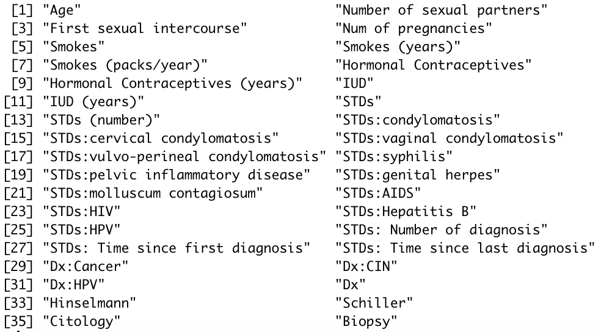

Many of these variable names contain space/colon/parantheses, which are not allowed in an R object name. To reference these variable names, you have to use backticks (e.g. `Smokes (year)`), which can cause a lot of problems.

Given that EHR data usually have a long list of variables, renaming all of them to be legitimate and nice R object names can be a tedious work. Here I provide a handy function `clean_names()` from the `janitor` package. Here shows the resulting variable names after I run `janitor::clean_names()` on the cervical cancer dataset I mentioned above.

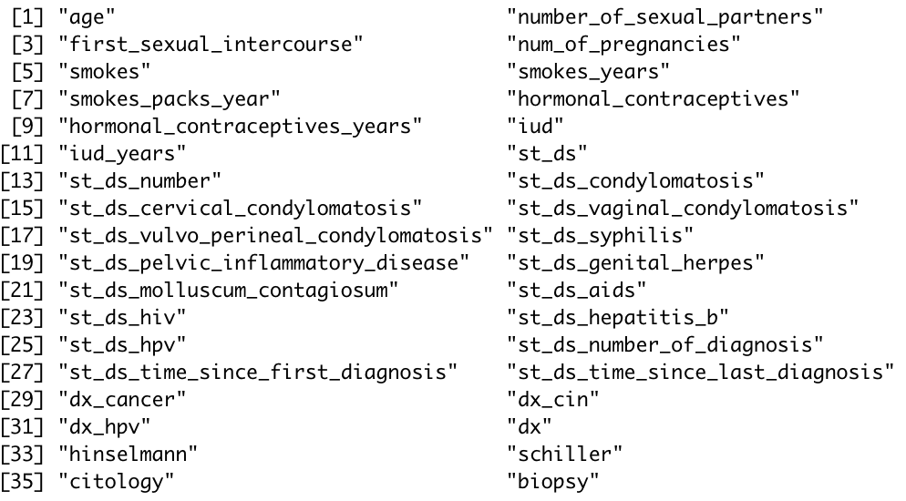

The default is to convert all variables names to be `snake_case`, but you can also use argument `case` to convert it to other style, like `CamelCase`. Options for `case` include “snake”, “small_camel”, “big_camel”, “screaming_snake”, “parsed”, “mixed”, “lower_upper”, “upper_lower”, “swap”, “all_caps”, “lower_camel”, “upper_camel”, “internal_parsing”, “none”, “flip”, “sentence”, “random” and “title”.

Now let’s use NHANES data to explore.

```r
# Show original NHANES variable names
NHANES %>%
  names %>%
  head(10)
```

```
##  [1] "ID"            "SurveyYr"      "Gender"        "Age"
##  [5] "AgeDecade"     "AgeMonths"     "Race1"         "Race3"
##  [9] "Education"     "MaritalStatus"
```

```r
# snake_case (default)
NHANES %>%
  janitor::clean_names() %>%
  names %>%
  head(10)
```

```
##  [1] "id"             "survey_yr"      "gender"         "age"
##  [5] "age_decade"     "age_months"     "race1"          "race3"
##  [9] "education"      "marital_status"
```

```r
# CamelCase
NHANES %>%
  janitor::clean_names(case = "big_camel") %>%
  names %>%
  head(10)
```

```
##  [1] "Id"            "SurveyYr"      "Gender"        "Age"
##  [5] "AgeDecade"     "AgeMonths"     "Race1"         "Race3"
##  [9] "Education"     "MaritalStatus"
```

```r
# Snake_Camel_Mixture
NHANES %>%
  janitor::clean_names(case = "mixed") %>%
  names %>%
  head(10)
```

```
##  [1] "Id"             "Survey_Yr"      "Gender"         "Age"
##  [5] "Age_Decade"     "Age_Months"     "Race1"          "Race3"
##  [9] "Education"      "Marital_Status"
```

```r
# All_CAPITAL
NHANES %>%
  janitor::clean_names(case = "all_caps") %>%
  names %>%
  head(10)
```

```
##  [1] "ID"             "SURVEY_YR"      "GENDER"         "AGE"
##  [5] "AGE_DECADE"     "AGE_MONTHS"     "RACE1"          "RACE3"
##  [9] "EDUCATION"      "MARITAL_STATUS"
```

**It is always a good habit to clean your variable names first after you read in your data.**

2. Curse of easy names

The philosophy of *dplyr* is to use plain language and easy words to describe the function. It leads to conflicts in function names with other packages at a cost. For example, `select` exists in both *dplyr* and *MASS* packages, `filter` exists in both *dplyr* and *stats* packages. Therefore, I would recommend you load your packages wisely - load the one you prefer to use later. If you can’t figure out where the conflict comes from, another workaround can alway be explicitly using `dplyr::select` or `dplyr::filter`.

3. Learning *data.table* from *dplyr* is easier with *dtplyr*

*Tidyverse* now includes a package called *dtplyr.* The goal of *dtplyr* is to allow you to write *dplyr* code that is automatically translated to the equivalent, but usually much faster, *data.table* code.

```r
library(dtplyr)

NHANES %>%
  lazy_dt %>%
  select(ID, Age, Gender, Diabetes) %>%
  filter(Age >= 18)
```

```
## Source: local data table [?? x 4]
## Call:   `_DT1`[, .(ID, Age, Gender, Diabetes)][Age >= 18]
##
##      ID   Age Gender Diabetes
##   <int> <int> <fct>  <fct>
## 1 51624    34 male   No
## 2 51624    34 male   No
## 3 51624    34 male   No
## 4 51630    49 female No
## 5 51647    45 female No
## 6 51647    45 female No
##
## # Use as.data.table()/as.data.frame()/as_tibble() to access results
```

`[, .(ID, Age, Gender, Diabetes)][Age >= 18]` in the Call is the translated *data.table* statement for the sequence of `select` and `filter` data manipulation work.